# ubc_mds_helper Tutorial

### Progress Visualization

The `visualize_program_progress()` function calculates how far along you are in the MDS program and saves a bar chart containing your progress to the `img/` folder. Also returns: - `capstone_progress_percentage`: progress from program start to the capstone start (0 to 1) - `completion_percentage`: progress from program start to the total program end (0 to 1)

```
Example 1: current_date = program_start
Capstone progress: 0
Program progress: 0

Example 2: current_date = capstone_start
Capstone progress: 1
Program progress: 0.7901639344262295

Example 3: passing date strings
Capstone progress: 0.5252100840336135
Program progress: 0.4098360655737705
```

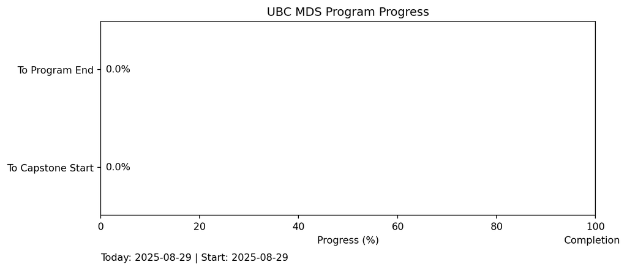

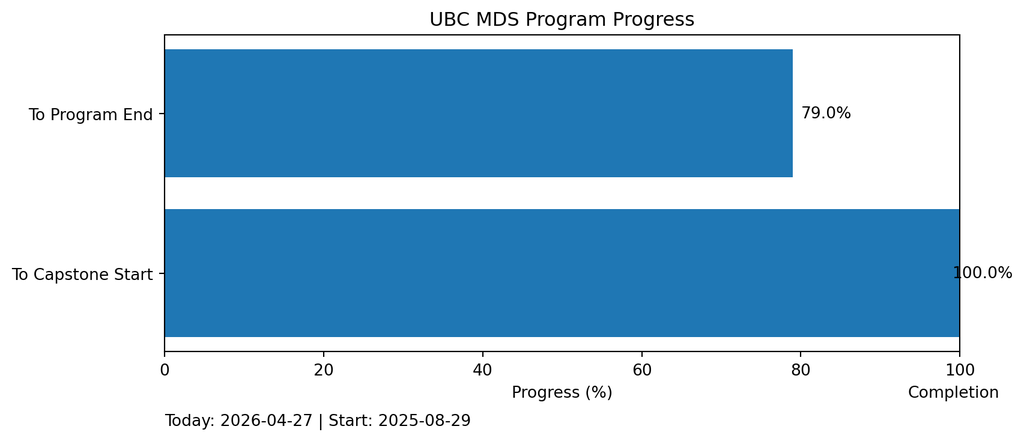

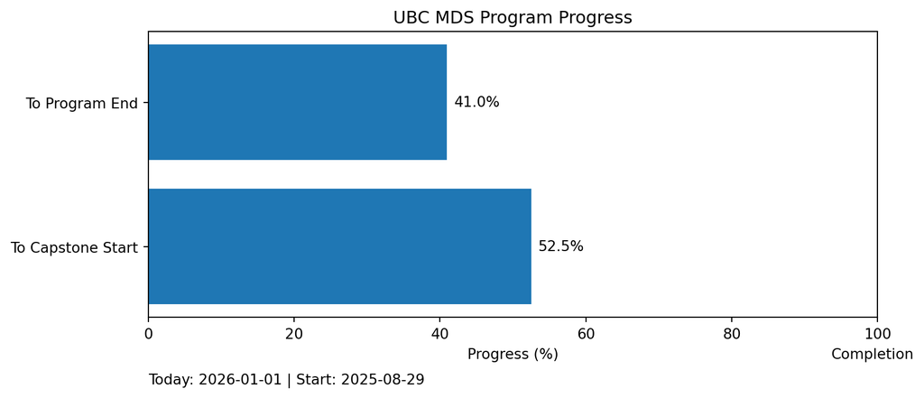

```python
from ubc_mds_helper.progress import visualize_program_progress
from ubc_mds_helper.config import PROGRAM_CONFIG_2025_2026

# pull the key dates from the config file
program_start = PROGRAM_CONFIG_2025_2026["program_start"]
capstone_start = PROGRAM_CONFIG_2025_2026["capstone"]["start"]
program_end = PROGRAM_CONFIG_2025_2026["program_end"]

# Example 1: If the current date = program start date: Progress equals 0.
print("\nExample 1: current_date = program_start")

capstone_completion_pct, program_completion_pct = visualize_program_progress(current_date = program_start)

print("Capstone progress:", capstone_completion_pct) # Expected: 0
print("Program progress:", program_completion_pct) # Expected: 0

# Example 2: If the current date = capstone start date: Capstone progress should equal 1 and program end progress should be less than 1.
print("\nExample 2: current_date = capstone_start")

capstone_completion_pct, program_completion_pct = visualize_program_progress(current_date = capstone_start)

print("Capstone progress:", capstone_completion_pct) # Expected: 1
print("Program progress:", program_completion_pct) # Expected: <FLOAT> < 1

# Example 3: Passing in date strings (works the same as datetime.date)
print("\nExample 3: passing date strings")

capstone_completion_pct, program_completion_pct = visualize_program_progress(
  current_date = "January 1, 2026",
  program_start_date = "August 29, 2025",
  program_end_date = "June 30, 2026",
  capstone_start_date = "April 24, 2026"
)

print("Capstone progress:", capstone_completion_pct) # Expected: <FLOAT> < 1
print("Program progress:", program_completion_pct) # Expected: <FLOAT> < 1
```

Keep in mind, the function also saves the progress bar chart to the img/ folder with the timestamp of the current date appended.